# Network Graph

igraph包

Humoon

2019-09-11

# 1 创建 graph 的标准过程

## 1.1 从数据框创建 graph

对于 graph 这种数据结构而言，最基本的元素包括节点（vertex）和边（节点之间的连线，edge）。igraph 这个R包提供了很多种创建 graph 的方式，我们先看一个最基本的例子，从数据框创建一个graph：

### 1.1.1 节点信息

```r
actors <- data.frame(
  name = c("Alice", "Bob", "Cecil", "David", "Esmeralda"),
  age = c(48,33,45,34,21),
  gender = c("F","M","F","M","F"))
actors
```

| name | age | gender |
| --- | --- | --- |
| Alice | 48 | F |
| Bob | 33 | M |
| Cecil | 45 | F |
| David | 34 | M |
| Esmeralda | 21 | F |

actors 这个数据框保存了图中所有节点的信息，共5个节点，有name, age, gender 3种属性。

### 1.1.2 边的信息

```r
relations <- data.frame(
  from = c("Bob", "Cecil", "Cecil", "David", "David", "Esmeralda"),
  to = c("Alice", "Bob", "Alice", "Alice", "Bob", "Alice"),
  same.dept = c(FALSE,FALSE,TRUE,FALSE,FALSE,TRUE),
  friendship = c(4,5,5,2,1,1), advice = c(4,5,5,4,2,3))
relations
```

| from | to | same.dept | friendship | advice |
| --- | --- | --- | --- | --- |
| Bob | Alice | FALSE | 4 | 4 |
| Cecil | Bob | FALSE | 5 | 5 |
| Cecil | Alice | TRUE | 5 | 5 |
| David | Alice | FALSE | 2 | 4 |
| David | Bob | FALSE | 1 | 2 |
| Esmeralda | Alice | TRUE | 1 | 3 |

relations 数据框保存了节点之间的连线信息， from、to 两列描述了这条边是从哪个节点到哪个检点，最后的3列是每条边的一些自定义的属性。

### 1.1.3 创建graph

当两个数据框创建完成之后，就可以利用 graph_from_data_frame 函数创建一个graph：

```r
g <- graph_from_data_frame(d = relations,
                           vertices = actors,
                           directed = F)
```

第一个参数是保存edge 信息的数据框，directed 参数控制graph 有无方向，vertices 参数是保存节点信息的数据框。

### 1.1.4 从graph对象访问节点属性和边的属性

```r
V(g)$name
```

```
[1] "Alice"     "Bob"       "Cecil"     "David"     "Esmeralda"
```

```r
V(g)$age
```

```
[1] 48 33 45 34 21
```

```r
E(g)$friendship
```

```
[1] 4 5 5 2 1 1
```

### 1.1.5 可视化：

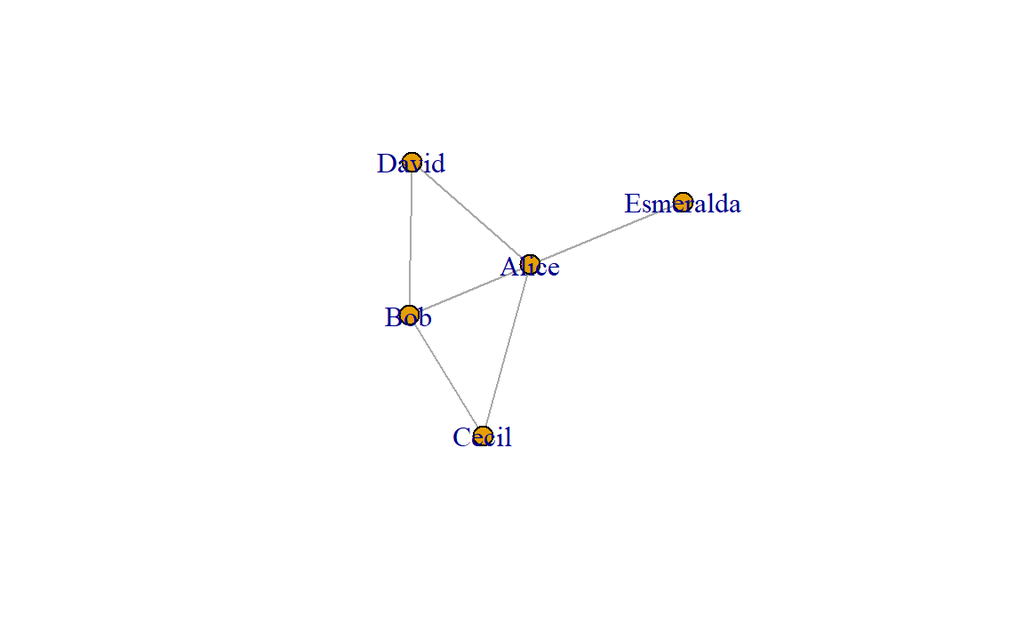

```r
plot(g)
```

### 1.1.6 布局算法layout

对于不同类型的 graph，有不同的自动化的布局算法。通过 layout 参数可以方便的指定，使用不同的布局算法：

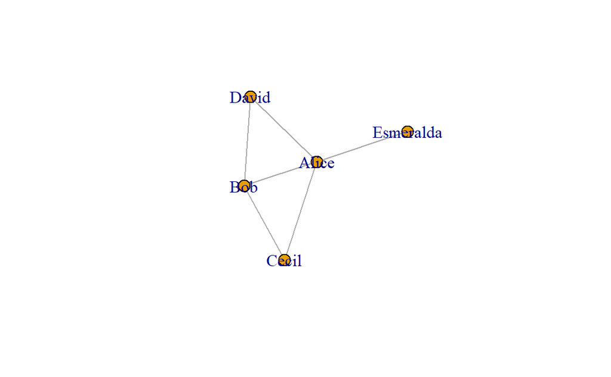

```r
plot(g, layout = layout.fruchterman.reingold)
```

### 1.1.7 统计网络的拓扑属性

```r
# 统计节点的度
degree(g, mode = "all")
```

```
    Alice       Bob     Cecil     David Esmeralda
        4         3         2         2         1
```

```r
# 统计密度
edge_density(g)
```

```
[1] 0.6
```

```r
# 统计clustering coefficient
transitivity(g, type = "global")
```

```
[1] 0.5455
```

```r
transitivity(g, type = "local")
```

```
[1] 0.3333 0.6667 1.0000 1.0000    NaN
```

```r
transitivity(g, type = "average")
```

```
[1] 0.75
```

### 1.1.8 挖掘聚类

`cluster_fast_greedy()`调用fast greedy algorithm算法，来预测community，其他聚类函数的用法和上述用法一致

```r
cfg <- cluster_fast_greedy(g)
plot(cfg, g)

# 节点对应的community信息可以从cfg这个对象中得到
cfg
```

```
IGRAPH clustering fast greedy, groups: 2, mod: -3.5e-17
+ groups:
  $`1`
  [1] "Alice"     "David"     "Esmeralda"

  $`2`
  [1] "Bob"   "Cecil"
```

[figure not shown]

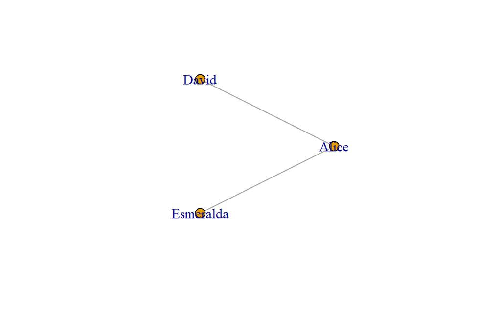

```r
# 对于每个community, 可以通过如下方式得到其子图，
nodes <- V(g)[cfg$membership == 1]
g_sub <- induced_subgraph(g, nodes)
plot(g_sub, layout = layout_in_circle)
```

## 1.2 例题

### 1.2.1 例1 边有权重

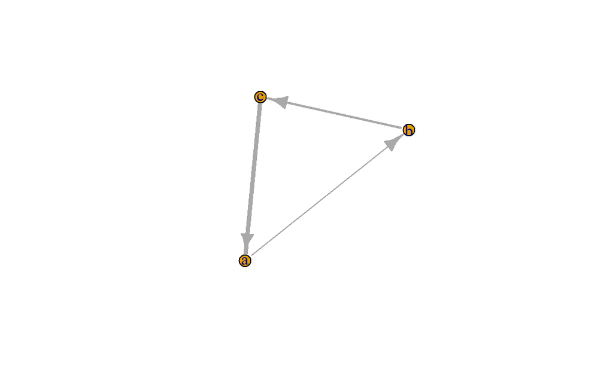

```r
d <- data.frame(p1 = c('a', 'b', 'c'), p2 = c('b', 'c', 'a'), weight = c(1, 2, 4))
g <- graph.data.frame(d, directed = TRUE) #有向图
plot(g, edge.width = E(g)$weight)
```

### 1.2.2